# Reproducible Research Project 1

```r
#load required packages
library(plyr)
library(dplyr)
#load the data and process
setwd("~/Downloads")
activity<-read.csv("activity.csv")
activity$date<-as.Date(activity$date)
```

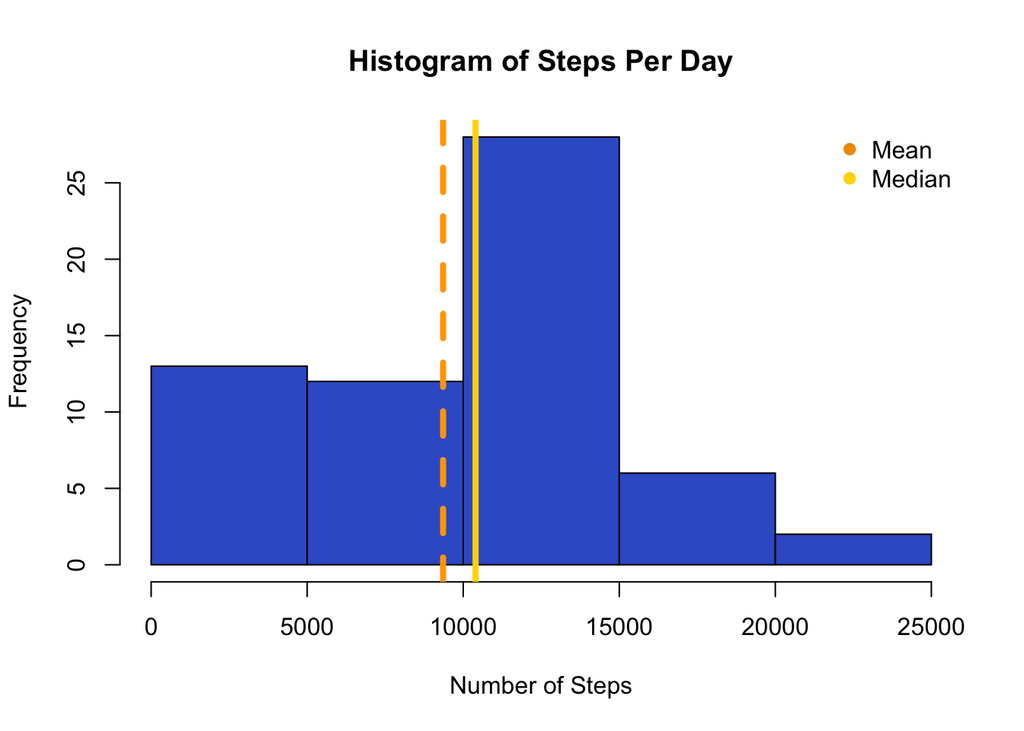

```r
steps.per.day<-ddply(activity,.(date),summarize,steps=sum(steps,na.rm=T))
par(mfrow=c(1,1))
hist(steps.per.day$steps,xlab="Number of Steps",ylab="Frequency",main="Histogram of Steps Per Day",col="royalblue3")
abline(v=mean(steps.per.day$steps),lwd=4,col="orange",lty=2)
abline(v=median(steps.per.day$steps),lwd=4,col="gold")
legend("topright",c("Mean","Median"),col=c("orange2","gold"),bty="n",pch=19)
```

```r
avg.steps.per.day<-tapply(activity$steps,activity$interval,mean,na.rm=T)
```

The plot above shows the histogram of total steps across the days in the data set. There are vertical lines for the mean and median. Note missing values are excluded from the data, but may lead to biased results if certain days have more missing values since we are calculating total steps. The mean total number of steps per day is 9354.2295082, and the median is 10395.

Here is the average number of steps taken in each five minute interval (averaged across days), which is depicted in the orange line. The blue points show the actual values, and there is high variance in some intervals. This plot omits missing values, which can skew values if data is missing non randomly across intervals. The five minute interval with the largest average number of steps is 835.

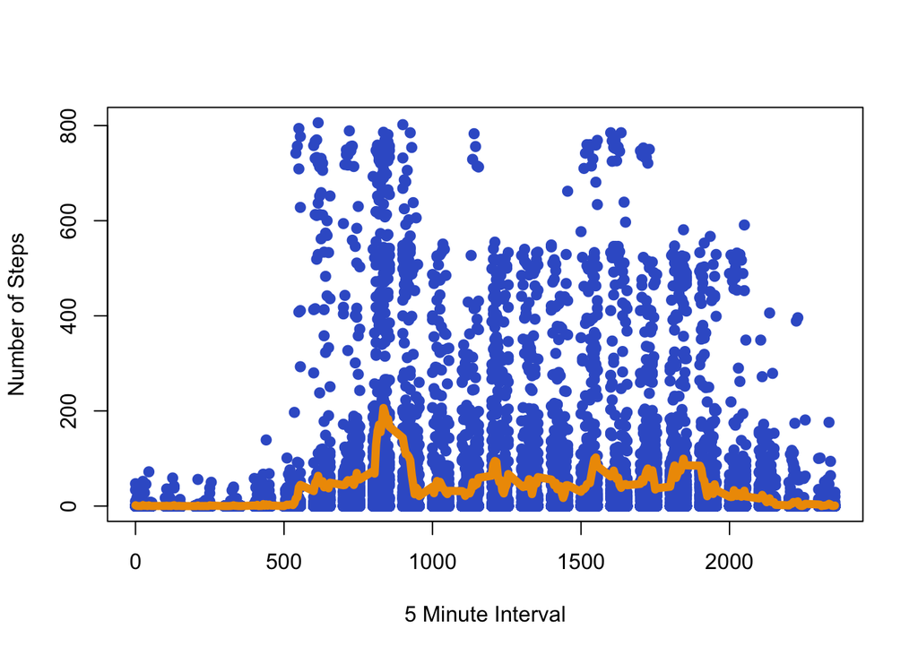

```r
par(mfrow=c(1,1))
plot(activity$interval,activity$steps,pch=19,col="royalblue3",xlab="5 Minute Interval",ylab="Number of Steps")
lines(names(avg.steps.per.day),avg.steps.per.day,type="l",col="orange2",lwd=6)
```